# Geospatial Data & Homeowners Insurance (With R)

Kevin McBeth, FCAS, MAAA

# Introduction

## Presenter

[figure not shown]

**Kevin McBeth, FCAS, MAAA**

Senior Vice President

Actuarial Operations

Arch Insurance

New York, NY

## Antitrust Notice

- The Casualty Actuarial Society is committed to adhering strictly to the letter and spirit of the antitrust laws. Seminars conducted under the auspices of the CAS are designed solely to provide a forum for the expression of various points of view on topics described in the programs or agendas for such meetings.
- Under no circumstances shall CAS seminars be used as a means for competing companies or firms to reach any understanding – expressed or implied – that restricts competition or in any way impairs the ability of members to exercise independent business judgment regarding matters affecting competition.
- It is the responsibility of all seminar participants to be aware of antitrust regulations, to prevent any written or verbal discussions that appear to violate these laws, and to adhere in every respect to the CAS antitrust compliance policy.

## Additional Disclaimers

- Some references to vendors. This is neither a comprehensive list nor an endorsement of specific vendors
- The views and opinions expressed in this presentation are my own and do not necessarily reflect those of my current or former employers. The views are my own understanding and interpretation of publicly available filings.
- I am not an attorney. Comments about state statutes should not be treated as legal advice.
- Artistic interpretation of data contained in filings.

## Slides

Slides on GitHub Pages:

[figure not shown]

Source code on GitHub:

[figure not shown]

## Outline

- Tech Stack
- Types of Geospatial Data
- Vector Data Sources
- Raster Data Sources
- Constructing Features
- Location-specific Data
- Modeling the Cost of Home Insurance
- Example Territory Maps
- Considerations
- Conclusion

## Tech Stack

- R
- Integrated Development Environments (IDEs)
  - RStudio - IDE from the company Posit (formerly named RStudio)
  - Positron - Visual Studio Code-based IDE from Posit
- Quarto - Presentation + code together
- GitHub - Source code control
- GitHub Pages - Publishing the rendered presentation online (automatically!)

## Tech Stack - R Libraries

```r
# Geospatial-specific
library(sf) # For working with vector geospatial data. Replaced rgdal and rgeos
library(terra) # For working with raster geospatial data. Replaced raster
terraOptions(progress = 0) # Turn off progress bars so they don't end up on slides
library(leaflet) # For interactive maps

# Others

library(curl) # For downloading files
library(readr) # For reading CSVs
library(dplyr) # For manipulating data

# Interface to JavaScript library DataTables
library(DT)
options(DT.options = list(pageLength = 8, ordering = FALSE))
```

## Tech Stack - Download Helper Function

Function to help download files if they don’t exist

```r
download_data <- function(url, relative_dir) {

  filename <- basename(url)
  dest_in <- paste("./data_in", relative_dir, filename, sep = "/")
  dest_mid <- paste("./data_mid", relative_dir, filename, sep = "/")

  if(!file.exists(dest_in)) {
    dir.create(dirname(dest_in), recursive = TRUE, showWarnings = FALSE)
    curl_download(url, dest_in)

    dir.create(dirname(dest_mid), recursive = TRUE, showWarnings = FALSE)
    unzip(dest_in, exdir = dirname(dest_mid))
  }

  dest_mid
}
```

# Geospatial Data Types

## Two Data Types

### Vector Data

Vector data represents the world using precise mathematical points, lines, and polygons. It is ideal for discrete objects with defined boundaries.

- Points: Specific XY coordinate locations (e.g., city landmarks, utility poles, or GPS waypoints).
- Lines: Connected points that represent linear features (e.g., roads, rivers, or flight paths).
- Polygons: Enclosed areas representing regions (e.g., property parcels, city limits, or lake boundaries).

### Raster Data

Raster data represents the world as a continuous surface divided into a grid of cells (pixels). Each cell contains a value representing information for that specific area.

- Grid Structure: Data is organized into rows and columns of equal-sized pixels.
- Continuous Values: Best for phenomena that change gradually over space (e.g., elevation, temperature, or satellite imagery).
- Resolution: The detail of the data depends on the pixel size; smaller pixels provide higher spatial resolution.

# Vector Sources

## Vector File Types

- Shapefile (.shp)
- GeoJSON (.geojson, .json)
- Keyhole Markup Language (KML, KMZ)
- Geography Markup Language (GML)
- GPS eXchange Format (GPX)
- GeoParquet (.parquet)

## Example Sources of Vector Data

- Census Bureau Boundary Shapefiles
- Longitude/Latitude Grids
- Any other territory boundary
- Soils Survey Geographic Database (USDA SSURGO)
- National Hurricane Center Hurricane Paths
- NOAA Severe Weather Data Inventory

## Census Bureau Shapefiles

- States
- Counties
- Cities
- ZIP Codes
- Tract
- Block Group
- Blocks

## States

**Download Shapefiles**

```r
url <- "https://www2.census.gov/geo/tiger/TIGER2025/STATE/tl_2025_us_state.zip"
dest_in <- "./data_in/census/TIGER2025/STATE/tl_2025_us_state.zip"
dest_mid <- "./data_mid/census/TIGER2025/STATE/tl_2025_us_state/tl_2025_us_state.zip"

if(!file.exists(dest_in)) {
  dir.create(dirname(dest_in), recursive = TRUE, showWarnings = FALSE)
  curl_download(url, dest_in)

  dir.create(dirname(dest_mid), recursive = TRUE, showWarnings = FALSE)
  unzip(dest_in, exdir = dirname(dest_mid))
}

dest_mid
```

**Read Census Shapefile and display data**

```r
# Read Census State Shapefile
census_state  <- read_sf("./data_mid/census/TIGER2025/STATE/tl_2025_us_state/tl_2025_us_state.shp")

# Print data table
census_state %>% arrange(STATEFP)
```

```
Simple feature collection with 56 features and 15 fields
Geometry type: MULTIPOLYGON
Dimension:     XY
Bounding box:  xmin: -179.2311 ymin: -14.60181 xmax: 179.8597 ymax: 71.43979
Geodetic CRS:  NAD83
# A tibble: 56 × 16
   REGION DIVISION STATEFP STATENS  GEOID GEOIDFQ     STUSPS NAME    LSAD  MTFCC
   <chr>  <chr>    <chr>   <chr>    <chr> <chr>       <chr>  <chr>   <chr> <chr>
 1 3      6        01      01779775 01    0400000US01 AL     Alabama 00    G4000
 2 4      9        02      01785533 02    0400000US02 AK     Alaska  00    G4000
 3 4      8        04      01779777 04    0400000US04 AZ     Arizona 00    G4000
 4 3      7        05      00068085 05    0400000US05 AR     Arkans… 00    G4000
 5 4      9        06      01779778 06    0400000US06 CA     Califo… 00    G4000
 6 4      8        08      01779779 08    0400000US08 CO     Colora… 00    G4000
 7 1      1        09      01779780 09    0400000US09 CT     Connec… 00    G4000
 8 3      5        10      01779781 10    0400000US10 DE     Delawa… 00    G4000
 9 3      5        11      01702382 11    0400000US11 DC     Distri… 00    G4000
10 3      5        12      00294478 12    0400000US12 FL     Florida 00    G4000
# ℹ 46 more rows
# ℹ 6 more variables: FUNCSTAT <chr>, ALAND <dbl>, AWATER <dbl>,
#   INTPTLAT <chr>, INTPTLON <chr>, geometry <MULTIPOLYGON [°]>
```

## New York Leaflet Plot

**Leaflet Code**

```r
census_state %>%
  filter(STUSPS == "NY") %>%
  leaflet() %>%
  addPolygons(weight = 0.5, opacity = 1.0)
```

[interactive chart not shown]

## New York Leaflet Plot With Basemap

**Leaflet Code**

```r
census_state %>%
  filter(STUSPS == "NY") %>%
  leaflet() %>%
  addTiles() %>% # Added OpenStreetMap Basemap
  addPolygons(weight = 0.5, opacity = 1.0)
```

[interactive chart not shown]

## Counties and County Equivalents

**Download and read in County Shapefile**

```r
url <- "https://www2.census.gov/geo/tiger/TIGER2025/COUNTY/tl_2025_us_county.zip"
dest_in <- "./data_in/census/TIGER2025/COUNTY/tl_2025_us_county.zip"
dest_mid <- "./data_mid/census/TIGER2025/COUNTY/tl_2025_us_county/tl_2025_us_county.zip"

if(!file.exists(dest_in)) {
  dir.create(dirname(dest_in), recursive = TRUE, showWarnings = FALSE)
  curl_download(url, dest_in)

  dir.create(dirname(dest_mid), recursive = TRUE, showWarnings = FALSE)
  unzip(dest_in, exdir = dirname(dest_mid))
}

# Read Census State Shapefile
census_county  <- read_sf("./data_mid/census/TIGER2025/COUNTY/tl_2025_us_county/tl_2025_us_county.shp")
```

**Leaflet County Map**

```r
census_county %>%
  filter(STATEFP == "36") %>%
  leaflet() %>%
  addTiles() %>% # Added OpenStreetMap Basemap
  addPolygons(weight = 0.5, opacity = 1.0)
```

[interactive chart not shown]

## Census Tracts

**Download and Read New York Census Tracts**

```r
url <- "https://www2.census.gov/geo/tiger/TIGER2025/TRACT/tl_2025_36_tract.zip"
dest_in <- "./data_in/census/TIGER2025/TRACT/tl_2025_36_tract.zip"
dest_mid <- "./data_mid/census/TIGER2025/TRACT/tl_2025_36_tract/tl_2025_36_tract.zip"

if(!file.exists(dest_in)) {
  dir.create(dirname(dest_in), recursive = TRUE, showWarnings = FALSE)
  curl_download(url, dest_in)

  dir.create(dirname(dest_mid), recursive = TRUE, showWarnings = FALSE)
  unzip(dest_in, exdir = dirname(dest_mid))
}

# Read Census State Shapefile
census_tracts  <- read_sf("./data_mid/census/TIGER2025/TRACT/tl_2025_36_tract/tl_2025_36_tract.shp")

new_york_county_tracts <- census_tracts %>%
  filter(STATEFP == "36", COUNTYFP == "061")
```

**Plot Manhattan Census Tracts**

```r
leaflet(new_york_county_tracts) %>%
  addTiles() %>%
  addPolygons(weight = 0.5, opacity = 1.0)
```

[interactive chart not shown]

## Census Block Groups

**Download and Read New York Census Block Groups**

```r
url <- "https://www2.census.gov/geo/tiger/TIGER2025/BG/tl_2025_36_bg.zip"
dest_in <- "./data_in/census/TIGER2025/BG/tl_2025_36_bg.zip"
dest_mid <- "./data_mid/census/TIGER2025/BG/tl_2025_36_bg/tl_2025_36_bg.zip"

if(!file.exists(dest_in)) {
  dir.create(dirname(dest_in), recursive = TRUE, showWarnings = FALSE)
  curl_download(url, dest_in)

  dir.create(dirname(dest_mid), recursive = TRUE, showWarnings = FALSE)
  unzip(dest_in, exdir = dirname(dest_mid))
}

new_york_county_bg  <- read_sf("data_mid/census/TIGER2025/BG/tl_2025_36_bg/tl_2025_36_bg.shp") %>%
  filter(STATEFP == "36", COUNTYFP == "061")
```

**Plot Manhattan Block Groups**

```r
leaflet(new_york_county_bg) %>%
  addTiles() %>%
  addPolygons(weight = 0.5, opacity = 1.0)
```

[interactive chart not shown]

## Census Blocks

**Download and Read New York Census Blocks**

```r
url <- "https://www2.census.gov/geo/tiger/TIGER2025/TABBLOCK20/tl_2025_36_tabblock20.zip"
dest_in <- "./data_in/census/TIGER2025/TABBLOCK20/tl_2025_36_tabblock20.zip"
dest_mid <- "./data_mid/census/TIGER2025/TABBLOCK20/tl_2025_36_tabblock20/tl_2025_36_tabblock20.zip"

if(!file.exists(dest_in)) {
  dir.create(dirname(dest_in), recursive = TRUE, showWarnings = FALSE)
  curl_download(url, dest_in)

  dir.create(dirname(dest_mid), recursive = TRUE, showWarnings = FALSE)
  unzip(dest_in, exdir = dirname(dest_mid))
}

new_york_county_blocks  <- read_sf("data_mid/census/TIGER2025/TABBLOCK20/tl_2025_36_tabblock20/tl_2025_36_tabblock20.shp") %>%
  filter(STATEFP20 == "36", COUNTYFP20 == "061") # Different field names
```

**Plot Manhattan Blocks**

```r
leaflet(new_york_county_blocks) %>%
  addTiles() %>%
  addPolygons(weight = 0.5, opacity = 1.0)
```

[interactive chart not shown]

## ZIP Codes (ZIP Code Tabulation Areas)

**Download and read in ZIP Code Tabulation Areas Shapefile**

```r
url <- "https://www2.census.gov/geo/tiger/TIGER2025/ZCTA520/tl_2025_us_zcta520.zip"
dest_in <- "./data_in/census/TIGER2025/ZCTA520/tl_2025_us_zcta520.zip"
dest_mid <- "./data_mid/census/TIGER2025/ZCTA520/tl_2025_us_zcta520/tl_2025_us_zcta520.zip"

if(!file.exists(dest_in)) {
  dir.create(dirname(dest_in), recursive = TRUE, showWarnings = FALSE)
  curl_download(url, dest_in)

  dir.create(dirname(dest_mid), recursive = TRUE, showWarnings = FALSE)
  unzip(dest_in, exdir = dirname(dest_mid))
}

# Read Shapefile
zcta  <- read_sf("./data_mid/census/TIGER2025/ZCTA520/tl_2025_us_zcta520/tl_2025_us_zcta520.shp")
```

```r
# Filter to New York, NY ZIP codes... sort of - Marble Hill Chopped off
zcta_manhattan <- zcta %>%
  filter(ZCTA5CE20 %in% c(as.character(seq(from = 10000, to = 10299))))

# Plot on top of Open Street Maps basemap
leaflet(zcta_manhattan) %>%
  addTiles() %>%
  addPolygons(weight = 0.5, opacity = 1.0)
```

[interactive chart not shown]

## ZIP Codes Pros/Cons

- Pros:
  - People know their ZIP Code
- Cons:
  - Any visual geographic boundary representation is an artistic interpretation of the ZIP + 4 file from the USPS, which is a list of 43 million addresses
  - They can cross city, county, and state boundaries
  - While individual address ZIP codes *are* mutually exclusive and exhaustive, territory representations are neither:
    - ZIP Codes overlap
    - Some areas with currently no population don’t get drawn inside a ZIP Code
  - There are 40,000+ changes per year. Visual representations like ZCTA don’t pick up all the changes immediately
  - Some ZIP codes only represent a single building

## Grids

- Grids are simpler
- Pre-existing grids:
  - 1 km x 1 km Military Grid Reference System (MGRS)
- Construct your own. Two examples:
  - 100 M x 100 M example
  - 0.01 Longitude x 0.01 Latitude

## Grids - 100 Meter x 100 Meter

```r
# Filter county data set to Manhattan
manhattan_county_utm <- census_county %>%
  filter(STATEFP == "36" & COUNTYFP == "061") %>%
  st_transform(crs = 32618) # This one's in meters

# 3. Create the grid
# cellsize is in the units of the CRS (meters)
grid <- st_make_grid(manhattan_county_utm, cellsize = c(100, 100), square = TRUE)

# 4. Convert grid to sf object and crop it to the island's shape
grid_sf <- st_sf(grid)
manhattan_custom_grid <- st_intersection(grid_sf, manhattan_county_utm) %>%
  st_transform(crs = st_crs(census_county)) # Transform back to line up with leaflet

# Plot
leaflet(manhattan_custom_grid) %>%
  addTiles() %>%
  addPolygons(weight = 0.5, opacity = 1.0)
```

[interactive chart not shown]

## Grids - 0.01 Longitude x 0.01 Latitude

```r
# Filter county data set to Manhattan
manhattan_county_4326 <- census_county %>%
  filter(STATEFP == "36" & COUNTYFP == "061") %>%
  st_transform(crs = st_crs(4326)) # This one's in meters

# 3. Create the grid
# cellsize is in the units of the CRS (meters)
grid_01 <- st_make_grid(manhattan_county_4326, cellsize = c(0.01, 0.01), square = TRUE)

# 4. Convert grid to sf object and crop it to the island's shape
grid_01_sf <- st_sf(grid_01)
manhattan_custom_01_grid <- st_intersection(grid_01_sf, manhattan_county_4326) %>%
  st_transform(crs = st_crs(census_county)) # Transform back to line up with leaflet

# Plot
leaflet(manhattan_custom_01_grid) %>%
  addTiles() %>%
  addPolygons(weight = 0.5, opacity = 1.0)
```

[interactive chart not shown]

## Shape Counts

```r
manhattan_territory_counts <- data.frame(
  type = c("ZIP Code Tabulation Areas", "Census Tracts", "Census Block Groups", "Census Blocks", "Grid: 0.01 x 0.01", "Grid: 100 m x 100 m"),
  count = c(
    nrow(zcta_manhattan),
    nrow(new_york_county_tracts),
    nrow(new_york_county_bg),
    nrow(new_york_county_blocks),
    nrow(manhattan_custom_01_grid),
    nrow(manhattan_custom_grid)))

datatable(manhattan_territory_counts, rownames = FALSE) %>%
  formatRound('count', digits = 0, mark = ",")
```

| type | count |
| --- | --- |
| ZIP Code Tabulation Areas | 69 |
| Census Tracts | 310 |
| Census Block Groups | 1292 |
| Census Blocks | 4043 |
| Grid: 0.01 x 0.01 | 132 |
| Grid: 100 m x 100 m | 9143 |

## Newer Geometries

- Spherical: s2 geometry
  - Used by Tinder
  - http://s2geometry.io/
  - https://r-spatial.github.io/s2/
- Hexagonal: h3 geometry
  - Used by Uber
  - https://h3geo.org/
- Hexagonal (probably not h3):
  - Alfa Mutual using 2,600 hexagons coverage Alabama.

## SSURGO

- Download **by county** from https://websoilsurvey.nrcs.usda.gov/app/WebSoilSurvey.aspx
- Shapefile with an ID
- Separate text files contain the data
  - [Documentation](https://www.nrcs.usda.gov/resources/data-and-reports/soil-survey-geographic-database-ssurgo)
- Sample variables
  - Drainage classification
  - Available water storage (varying depths)
  - Bedrock Depth
  - Ponding Frequency

## SSURGO - Manhattan - Available Water Storage to 50 CM

**Download Soil Survey Data & Create Names**

```r
download_data(
  url = "https://websoilsurvey.sc.egov.usda.gov/DSD/Download/Cache/SSA/wss_SSA_NY061_soildb_US_2003_[2025-08-28].zip",
  relative_dir = "ssurgo")

muaggatt_names <- c(
  "musym",
  "muname",
  "mustatus",
  "slopegraddcp",
  "slopegradwta",
  "brockdepmin",
  "wtdepannmin",
  "wtdepaprjunmin",
  "flodfreqdcd",
  "flodfreqmax",
  "pondfreqprs",
  "aws025wta",
  "aws050wta",
  "aws0100wta",
  "aws0150wta",
  "drclassdcd",
  "drclasswettest",
  "hydgrpdcd",
  "iccdcd",
  "iccdcdpct",
  "niccdcd",
  "niccdcdpct",
  "engdwobdcd",
  "engdwbdcd",
  "engdwbll",
  "engdwbml",
  "engstafdcd",
  "engstafll",
  "engstafml",
  "engsldcd",
  "engsldcp",
  "englrsdcd",
  "engcmssdcd",
  "engcmssmp",
  "urbrecptdcd",
  "urbrecptwta",
  "forpehrtdcp",
  "hydclprs",
  "awmmfpwwta",
  "mukey")

muaggatt_types <- c("cclnnnnnccnnnnnccclnnncccccccccccccncnnc")
```

```r
# Read muaggatt data file for New York County
muaggatt <- read_delim(
  "data_mid/ssurgo/NY061/tabular/muaggatt.txt", delim = "|",
  col_names = muaggatt_names,
  col_types = muaggatt_types)

# Read shapefile for New York, NY county
ssurgo <- read_sf("data_mid/ssurgo/NY061/spatial/soilmu_a_ny061.shp") %>%
  left_join(muaggatt, c ("MUKEY" = "mukey"))

# Define color palate - these are always annoying
aws_pal <- colorBin("Blues", ssurgo$aws050wta, 5, pretty = FALSE)

# Create available water storage plot plot
leaflet(ssurgo) %>%
  addPolygons(weight = 0.5,
              opacity = 1.0, fillOpacity = 1.0,
              fillColor = ~aws_pal(aws050wta)) %>%
  addLegend(
    pal = aws_pal,
    values = ~aws050wta,
    position = "bottomright",
  title = "Available Water Storage to a Depth of 50 CM")
```

[interactive chart not shown]

# Raster Data Sources

(Slightly Bended Pictures)

## National Land Cover Dataset (NLCD)

Giant Raster (pixel) image

**Download NLCD Raster**

```r
url <- "https://www.mrlc.gov/downloads/sciweb1/shared/mrlc/data-bundles/Annual_NLCD_LndCov_2024_CU_C1V1.zip"
dest_in <- "./data_in/nlcd/Annual_NLCD_LndCov_2024_CU_C1V1.zip"
dest_mid <- "./data_mid/nlcd/Annual_NLCD_LndCov_2024_CU_C1V1.zip"

if(!file.exists(dest_in)) {
  dir.create(dirname(dest_in), recursive = TRUE, showWarnings = FALSE)
  curl_download(url, dest_in)

  dir.create(dirname(dest_mid), recursive = TRUE, showWarnings = FALSE)
  unzip(dest_in, exdir = dirname(dest_mid))
}

dest_mid
```

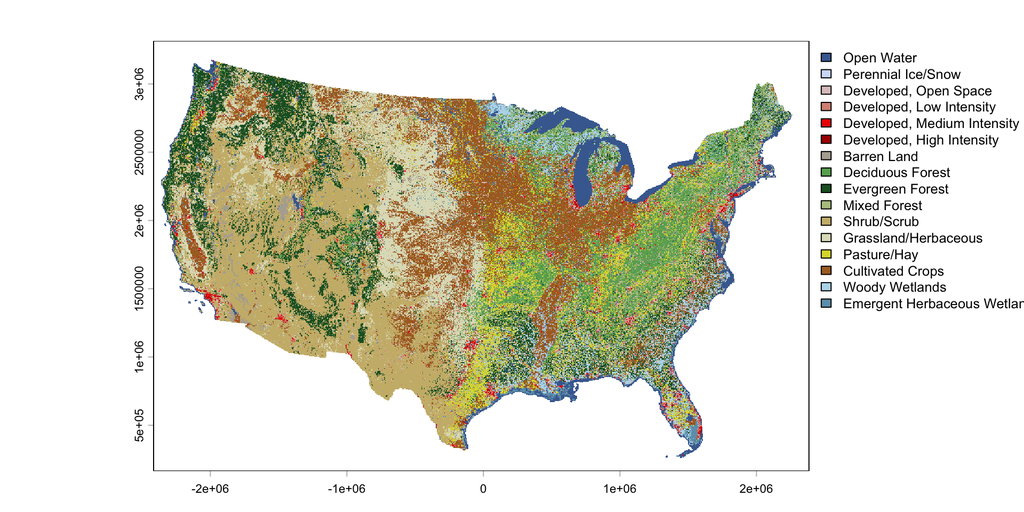

```r
nlcd <- rast("data_mid/nlcd/Annual_NLCD_LndCov_2024_CU_C1V1.tif")
plot(nlcd)
```

## NLCD in Manhattan

```r
manhattan_county <- census_county %>%
  filter(GEOID == "36061") %>%
  st_transform(crs(nlcd))

# Mask = TRUE crops to the boards rather than a rectangle
nlcd_man <- crop(nlcd, manhattan_county, mask = TRUE)
```

```r
leaflet() %>%
addTiles() %>%
  addRasterImage(nlcd_man, opacity = 0.8) %>%
  addRasterLegend(nlcd_man, title = "NLCD Land Cover", opacity = 1)
```

[interactive chart not shown]

## USGS Digital Elevation Map (DEM)

```r
url <- c("https://prd-tnm.s3.amazonaws.com/StagedProducts/Elevation/13/TIFF/current/n41w075/USGS_13_n41w075.tif",
         "https://prd-tnm.s3.amazonaws.com/StagedProducts/Elevation/13/TIFF/current/n41w074/USGS_13_n41w074.tif")
dest_in <- c("./data_in/dem/USGS_13_n41w075.tif","./data_in/dem/USGS_13_n41w074.tif")

for(i in 1:length(url)){
  if(!file.exists(dest_in[i])) {
    dir.create(dirname(dest_in[i]), recursive = TRUE, showWarnings = FALSE)
    curl_download(url[i], dest_in[i])
  }
}
```

**Merge and display DEM**

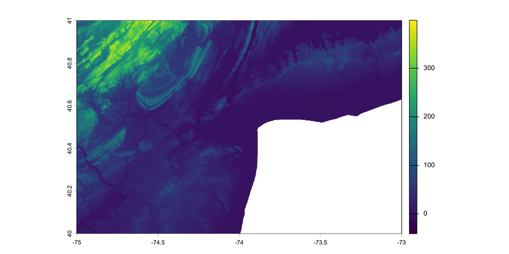

```r
dem <- merge(
  rast("data_in/dem/USGS_13_n41w075.tif"),
  rast("data_in/dem/USGS_13_n41w074.tif"))

plot(dem)
```

# Feature Engineering

## Center Value

- Fast way of assigning **something** to each territory
- A single point may or may not be representative of the entire territory
- Using the centroid here, but internal point may be better

```r
# Transform CRS to match NLCD
new_york_county_tracts_nlcd_crs <- st_transform(new_york_county_tracts, crs(nlcd))

# Calculate the centroids of the tracts
centroids <- st_centroid(new_york_county_tracts_nlcd_crs)

# Extract values at centroids
centroid_values <- extract(nlcd, centroids, layer = 1)

# Read in land cover descriptions
nlcd_descriptions <- read_csv("data_in/nlcd/nlcd_classes.csv")

# Bind data
centroid_values <- centroids %>%
  st_drop_geometry() %>% # Removes the geometry so we get a datatable
  bind_cols(centroid_values) %>%
  dplyr::select(GEOID, land_cover_code = value) %>%
  left_join(nlcd_descriptions) %>%
  arrange(GEOID, land_cover_code)
```

## Centroid Data Table

```r
datatable(centroid_values, rownames = FALSE)
```

| GEOID | land_cover_code | land_cover_desc | class |
| --- | --- | --- | --- |
| 36061000100 | 11 | Open Water | Water |
| 36061000201 | 24 | Developed High Intensity | Developed |
| 36061000202 | 11 | Open Water | Water |
| 36061000500 | 21 | Developed, Open Space | Developed |
| 36061000600 | 24 | Developed High Intensity | Developed |
| 36061000700 | 11 | Open Water | Water |
| 36061000800 | 23 | Developed, Medium Intensity | Developed |
| 36061000900 | 11 | Open Water | Water |
| 36061001001 | 11 | Open Water | Water |
| 36061001002 | 11 | Open Water | Water |

[output cut: 300 more lines]

## Overlap

- Mask the raster with the shapes and summarize the data that fall within each shape
- Amount of data depends on the size of the territory
- Small territories have less data than large ones

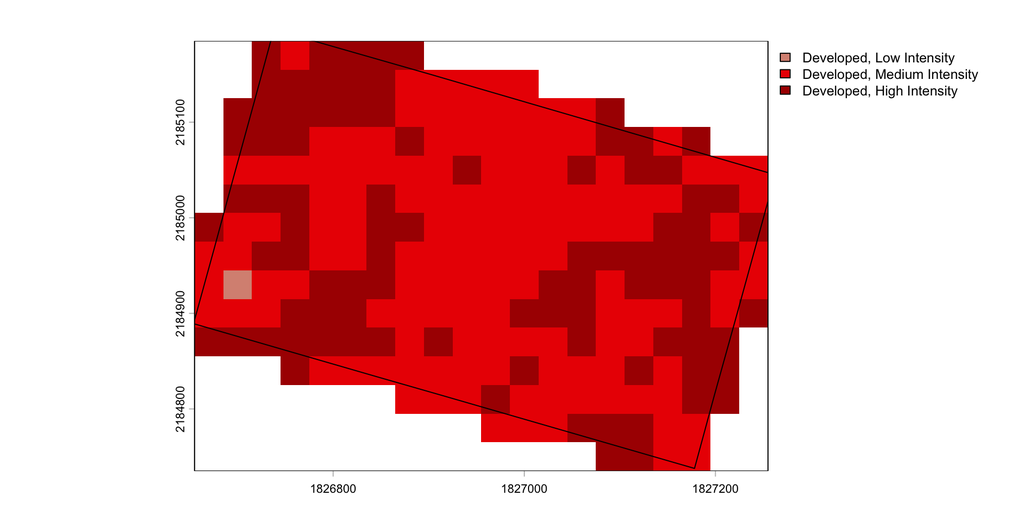

```r
# Example
selected_shape <- "36061013100" # Sheraton New York Times Square Hotel Census Tract
tract <- filter(new_york_county_tracts_nlcd_crs, GEOID == selected_shape)

cropped_raster <- crop(nlcd, ext(tract)) # Cropping first makes this faster
masked_raster <- mask(cropped_raster, tract)

plot(masked_raster)
plot(tract, add = TRUE, col = NA, title = selected_shape)
```

Then compute whatever static you want to try: min, median, average, max, predominant

## Masked Output Table

```r
for (i in 1:nrow(new_york_county_tracts_nlcd_crs)) {
  if(i == 1) {
    all_data <- NULL
  }

  shape <- new_york_county_tracts_nlcd_crs[i,]
  GEOID <- new_york_county_tracts_nlcd_crs$GEOID[i]

  cropped_raster <- crop(nlcd, ext(shape)) # Cropping first makes this faster
  masked_raster <- mask(cropped_raster, shape)

  all_data[[i]] <- data.frame(cbind(GEOID = GEOID, freq(masked_raster, bylayer = FALSE)))
}

masked_freq <- bind_rows(all_data) %>%
  mutate(count = as.numeric(count)) %>%
  rename(land_cover = value) %>%
  arrange(GEOID, land_cover)


datatable(masked_freq, rownames = FALSE)
```

| GEOID | land_cover | count |
| --- | --- | --- |
| 36061000100 | Barren Land | 1 |
| 36061000100 | Developed, High Intensity | 17 |
| 36061000100 | Developed, Low Intensity | 24 |
| 36061000100 | Developed, Medium Intensity | 47 |
| 36061000100 | Developed, Open Space | 6 |
| 36061000100 | Grassland/Herbaceous | 5 |
| 36061000100 | Open Water | 15 |
| 36061000201 | Developed, High Intensity | 95 |
| 36061000201 | Developed, Low Intensity | 2 |
| 36061000201 | Developed, Medium Intensity | 38 |

[output cut: 1000 more lines]

## Masked Pecent Land Cover

```r
# Percent of ZIP for each land cover
masked_percent <- masked_freq %>%
  group_by(GEOID) %>%
  mutate(percent = count / sum(count)) %>%
  arrange(GEOID, land_cover)

datatable(masked_percent, rownames = FALSE) %>%
  formatPercentage('percent', digits = 1)
```

| GEOID | land_cover | count | percent |
| --- | --- | --- | --- |
| 36061000100 | Barren Land | 1 | 0.008695652173913044 |
| 36061000100 | Developed, High Intensity | 17 | 0.1478260869565217 |
| 36061000100 | Developed, Low Intensity | 24 | 0.208695652173913 |
| 36061000100 | Developed, Medium Intensity | 47 | 0.4086956521739131 |
| 36061000100 | Developed, Open Space | 6 | 0.05217391304347826 |
| 36061000100 | Grassland/Herbaceous | 5 | 0.04347826086956522 |
| 36061000100 | Open Water | 15 | 0.1304347826086956 |
| 36061000201 | Developed, High Intensity | 95 | 0.4025423728813559 |
| 36061000201 | Developed, Low Intensity | 2 | 0.00847457627118644 |
| 36061000201 | Developed, Medium Intensity | 38 | 0.1610169491525424 |

[output cut: 1000 more lines]

## Masked Predominant Land Cover

```r
# Predominant land cover
masked_predominant <- masked_freq %>%
  group_by(GEOID) %>%
  arrange(GEOID, desc(count)) %>%
  top_n(1) # Grabs the most common / predominant cover

datatable(masked_predominant, rownames = FALSE)
```

| GEOID | land_cover | count |
| --- | --- | --- |
| 36061000100 | Developed, Medium Intensity | 47 |
| 36061000201 | Open Water | 101 |
| 36061000202 | Open Water | 501 |
| 36061000500 | Open Water | 3904 |
| 36061000600 | Developed, High Intensity | 186 |
| 36061000700 | Open Water | 311 |
| 36061000800 | Developed, High Intensity | 230 |
| 36061000900 | Open Water | 569 |
| 36061001001 | Open Water | 269 |
| 36061001002 | Open Water | 262 |

[output cut: 300 more lines]

## Buffering

- Draw a square or circular buffer around each centroid
- More consistent number of data elements
- May fall short or go beyond the edges of the shape
- Edges of the data set become problematic
- This example uses circles

## Buffering Example

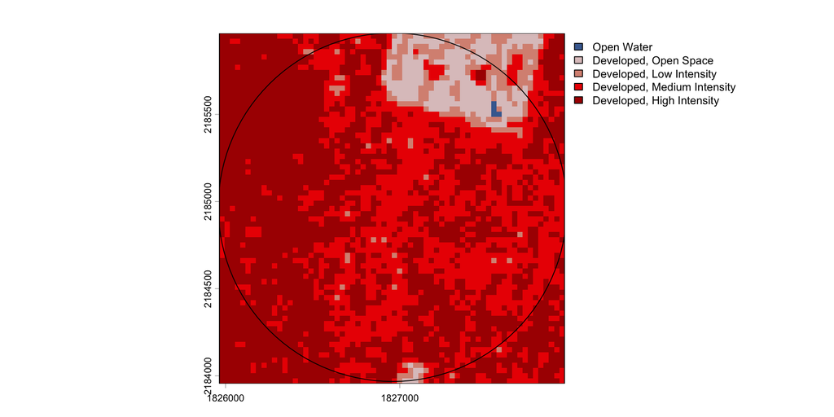

```r
# Create buffers
buffers <- st_buffer(centroids, dist = 1000)  # 1 km buffer

# Loop through ZIPs
for (i in 1:nrow(buffers)) {
#for (i in 1:1) {
  if(i == 1) {
    all_data <- NULL
  }

  selected_buffer <- buffers[i,]
  selected_GEOID <- buffers$GEOID[i]

  # Crop and mask
  cropped_raster <- crop(nlcd, ext(selected_buffer)) # Cropping first makes this faster
  masked_raster <- mask(cropped_raster, selected_buffer)

  # Calculate frequencies
  all_data[[i]] <- data.frame(cbind(GEOID = selected_GEOID, freq(masked_raster, bylayer = FALSE)))
}

# Build the complete data set
buffered_freq <- bind_rows(all_data) %>%
  mutate(count = as.numeric(count)) %>%
  rename(land_cover = value) %>%
  arrange(GEOID, land_cover)

# Example

selected_geoid <- "36061013100"
selected_buffer <- filter(buffers, GEOID == selected_geoid)

cropped_raster <- crop(nlcd, ext(selected_buffer)) # Cropping first makes this faster
masked_raster <- mask(cropped_raster, selected_buffer)

plot(cropped_raster)
plot(selected_buffer, col = NA,  add = TRUE, title = selected_geoid)
```

## Buffered Output Table

```r
datatable(buffered_freq, rownames = FALSE)
```

| GEOID | land_cover | count |
| --- | --- | --- |
| 36061000100 | Barren Land | 11 |
| 36061000100 | Deciduous Forest | 5 |
| 36061000100 | Developed, High Intensity | 20 |
| 36061000100 | Developed, Low Intensity | 114 |
| 36061000100 | Developed, Medium Intensity | 116 |
| 36061000100 | Developed, Open Space | 78 |
| 36061000100 | Emergent Herbaceous Wetlands | 34 |
| 36061000100 | Grassland/Herbaceous | 27 |
| 36061000100 | Open Water | 3193 |
| 36061000100 | Woody Wetlands | 1 |

[output cut: 1648 more lines]

## Buffered Predominant Land Cover

```r
# Predominant land cover
buffered_predominant <- buffered_freq %>%
  group_by(GEOID) %>%
  arrange(GEOID, desc(count)) %>%
  top_n(1)

datatable(buffered_predominant, rownames = FALSE)
```

| GEOID | land_cover | count |
| --- | --- | --- |
| 36061000100 | Open Water | 3193 |
| 36061000201 | Developed, High Intensity | 1521 |
| 36061000202 | Open Water | 1456 |
| 36061000500 | Open Water | 2746 |
| 36061000600 | Developed, High Intensity | 1713 |
| 36061000700 | Open Water | 1621 |
| 36061000800 | Developed, High Intensity | 1878 |
| 36061000900 | Open Water | 2178 |
| 36061001001 | Open Water | 1446 |
| 36061001002 | Open Water | 1338 |

[output cut: 300 more lines]

## Buffered Percent Land Cover

```r
# Percent of ZIP for each land cover
buffered_percent <- buffered_freq %>%
  group_by(GEOID) %>%
  mutate(percent = count / sum(count)) %>%
  arrange(GEOID, land_cover)

datatable(buffered_percent, rownames = FALSE) %>%
  formatPercentage('percent', digits = 1)
```

| GEOID | land_cover | count | percent |
| --- | --- | --- | --- |
| 36061000100 | Barren Land | 11 | 0.003056404556821339 |
| 36061000100 | Deciduous Forest | 5 | 0.001389274798555154 |
| 36061000100 | Developed, High Intensity | 20 | 0.005557099194220617 |
| 36061000100 | Developed, Low Intensity | 114 | 0.03167546540705751 |
| 36061000100 | Developed, Medium Intensity | 116 | 0.03223117532647958 |
| 36061000100 | Developed, Open Space | 78 | 0.0216726868574604 |
| 36061000100 | Emergent Herbaceous Wetlands | 34 | 0.009447068630175049 |
| 36061000100 | Grassland/Herbaceous | 27 | 0.007502083912197833 |
| 36061000100 | Open Water | 3193 | 0.8871908863573215 |
| 36061000100 | Woody Wetlands | 1 | 0.0002778549597110308 |

[output cut: 1648 more lines]

## Masked vs. Buffered

```r
# full_join data sets
masked_vs_buffered_percent <- masked_percent %>%
  full_join(buffered_percent, by = c("GEOID", "land_cover"), suffix = c("_mask", "_buff")) %>%
  rename_with(~ gsub("percent", "pct", .x), contains("percent")) %>%
  rename_with(~ gsub("count", "cnt", .x), contains("count"))

datatable(masked_vs_buffered_percent, rownames = FALSE) %>%
  formatPercentage('pct_mask', digits = 1) %>%
  formatPercentage('pct_buff', digits = 1)
```

| GEOID | land_cover | cnt_mask | pct_mask | cnt_buff | pct_buff |
| --- | --- | --- | --- | --- | --- |
| 36061000100 | Barren Land | 1 | 0.008695652173913044 | 11 | 0.003056404556821339 |
| 36061000100 | Developed, High Intensity | 17 | 0.1478260869565217 | 20 | 0.005557099194220617 |
| 36061000100 | Developed, Low Intensity | 24 | 0.208695652173913 | 114 | 0.03167546540705751 |
| 36061000100 | Developed, Medium Intensity | 47 | 0.4086956521739131 | 116 | 0.03223117532647958 |
| 36061000100 | Developed, Open Space | 6 | 0.05217391304347826 | 78 | 0.0216726868574604 |
| 36061000100 | Grassland/Herbaceous | 5 | 0.04347826086956522 | 27 | 0.007502083912197833 |
| 36061000100 | Open Water | 15 | 0.1304347826086956 | 3193 | 0.8871908863573215 |
| 36061000201 | Developed, High Intensity | 95 | 0.4025423728813559 | 1521 | 0.4210963455149502 |
| 36061000201 | Developed, Low Intensity | 2 | 0.00847457627118644 | 77 | 0.02131782945736434 |
| 36061000201 | Developed, Medium Intensity | 38 | 0.1610169491525424 | 843 | 0.2333887043189369 |

[output cut: 1648 more lines]

## Masked vs. Buffered - NAs

```r
# Filter to nulls
masked_vs_buffered_percent_null <- masked_vs_buffered_percent %>%
  filter(is.na(cnt_mask) | is.na(cnt_buff))

datatable(masked_vs_buffered_percent_null, rownames = FALSE) %>%
  formatPercentage('pct_mask', digits = 1) %>%
  formatPercentage('pct_buff', digits = 1)
```

| GEOID | land_cover | cnt_mask | pct_mask | cnt_buff | pct_buff |
| --- | --- | --- | --- | --- | --- |
| 36061000100 | Deciduous Forest |  |  | 5 | 0.001389274798555154 |
| 36061000100 | Emergent Herbaceous Wetlands |  |  | 34 | 0.009447068630175049 |
| 36061000100 | Woody Wetlands |  |  | 1 | 0.0002778549597110308 |
| 36061000201 | Developed, Open Space |  |  | 8 | 0.00221483942414175 |
| 36061000201 | Emergent Herbaceous Wetlands |  |  | 2 | 0.0005537098560354374 |
| 36061000600 | Developed, Open Space |  |  | 9 | 0.002489626556016597 |
| 36061000600 | Emergent Herbaceous Wetlands |  |  | 1 | 0.000276625172890733 |
| 36061000700 | Developed, Open Space |  |  | 9 | 0.002499305748403221 |
| 36061000700 | Emergent Herbaceous Wetlands |  |  | 1 | 0.0002777006387114691 |
| 36061000800 | Developed, Open Space |  |  | 4 | 0.001110802554845876 |

[output cut: 638 more lines]

# Location-specific Data

## Where is the propety?

- Geocoding
  - Lots of providers. Three examples:
    - ESRI ArcGIS: https://developers.arcgis.com/rest/geocode/geocode-addresses/
    - Google Maps: https://developers.google.com/maps/documentation/geocoding/reference/rest/v4beta/GeocodeResult.Granularity
    - mapbox: https://docs.mapbox.com/api/search/geocoding/
  - Single point
  - Mailbox vs. building
  - May not be accurate, particularly for new properties
- Building Footprints
  - Outline of the entire building
  - https://onegeo.co/documentation/api/
  - https://planetarycomputer.microsoft.com/dataset/ms-buildings#overview
  - https://dataforgood.facebook.com/dfg/tools/buildings

# Example Territory Maps

A review of the three largest New York Home Insurance Companies

## No. 3: Chubb (626) - Chubb National Insurance Company (10052)

Three Perils:

- Hurricane Wind
- Non-Hurricane Wind
- All Other Perils

Territories:

- A gnarly mix of county, town, ZIP codes, and islands

For example, New York County is split into three pieces:

- Governors Island - Territory 97
- Fort Charles - Territory 05
- Rest of County - Territory 18

I’m not even going to try…

## No 2: Allstate Insurance Group

Allstate Vehicle and Property Insurance Company (37907)

ZIP Code-based territories

12 perils:

- Fire 1
- Fire 2
- Brush Fire
- Water Weather
- Water Non-weather
- Wind
- Hail
- Lightning
- Theft
- Liability
- Hurricane
- Other

```r
# Read in Allstate factor table
allstate_ny <- read_csv("./references_private/allstate_factors.csv",
                        col_names = c("zip",
                                      "fire1", "fire2", "brush_fire", "water_weather",
                                      "water_nonweather", "wind", "hail", "lightning",
                                      "theft", "liability", "hurricane", "other"),
                        skip = 1)

# Join factors to ZIP shapefile
zip_allstate_ny <- zcta %>%
  inner_join(allstate_ny, by = c("ZCTA5CE20" = "zip"))
```

## State Farm Group (176)

State Farm Group (176)

State Farm Fire And Casualty Company (25143)

Ranked #1 in NY ($1.2B in 2024 Direct Written Premium)

- Granularity: “Location Rating” Grid
  - Decimal degrees to two decimal places
- 2 Perils:
  - Hurricane
  - Non-Hurricane
- Source: 4,637 PDF pages of data

## State Farm Fire And Casualty Company (25143) - Non-Hurricane Factors

```r
# Starts extracting the table from PDF
sf_ny <- read_csv("./references_private/state_farm_20200715.csv", col_names = c("GRID_ID", "HURR_FCTR", "NONHURR_FCTR"))  %>%
  mutate( # This parses the coordinate out of GRID_ID
    y =   0.01 * as.numeric(substr(GRID_ID, 1, 5)),
    x = - 0.01 * as.numeric(substr(GRID_ID, 6, 10)))

# Turn it into a raster
nonhurr_ny <- rast(sf_ny[, c("x", "y", "NONHURR_FCTR")], crs = crs('+proj=longlat +datum=WGS84'))

# Set up a color palette
pal <- colorBin(
  palette = c("#2c7bb6", "#abd9e9","#ffffbf","#fdae61","#d7191c"),
  domain = values(nonhurr_ny),
  bins = c(0.75, 1.0, 1.25, 1.5, 1.75),
  na.color = "transparent"
)

# Useful for seeing how frequent factors are
# Override digits since it rounds to integers by default
# freq(nonhurr_ny, digits = 3)
leaflet() %>%
  addTiles() %>%
  addRasterImage(nonhurr_ny, colors = pal, opacity = 0.5) %>%
  addLegend(pal = pal, values = values(nonhurr_ny), title = "Non-Hurricane Factor")
```

[interactive chart not shown]

## State Farm Fire And Casualty Company (25143) - Hurricane Factors

```r
# Turn it into a raster
hurr_ny <- rast(sf_ny[, c("x", "y", "HURR_FCTR")], crs = crs('+proj=longlat +datum=WGS84'))

# Set up a color palette
pal <- colorBin(
  palette = c("#2c7bb6", "#abd9e9","#ffffbf","#fdae61","#d7191c"),
  domain = values(hurr_ny),
  bins = c(0, 0.5, 1.5, 2.0, 2.5, 3.0),
  na.color = "transparent"
)

leaflet() %>%
  addTiles() %>%
  addRasterImage(hurr_ny, colors = pal, opacity = 0.5) %>%
  addLegend(pal = pal, values = values(hurr_ny), title = "Hurricane Factor")
```

[interactive chart not shown]